# MEML_PS01_Linear_Algebra_Soln

**Machine Learning for Mechanical Engineering**  
**Solution of Linear Algebra**

Prof. Seungchul Lee  
http://iailab.kaist.ac.kr/  
Industrial AI Lab at KAIST

- For your handwritten solutions, please scan or take a picture of them. Alternatively, you can write them in markdown if you prefer.
- Only .ipynb files will be graded for your code.
  - Ensure that your NAME and student ID are included in your .ipynb files. ex) SeungchulLee_20241234_HW01.ipynb
- Compress all the files into a single .zip file.
  - In the .zip file's name, include your NAME and student ID. ex) SeungchulLee_20241234_HW01.zip
  - Submit this .zip file on KLMS
- Do not submit a printed version of your code, as it will not be graded.

# Problem 01

Let $x$ be a block vector with two vector elements, $x = \begin{bmatrix}a\\b\end{bmatrix}$ where $a$ and $b$ are vectors of size $n$ and $m$, respectively. Show that

$$\lVert x \rVert = \left(\lVert a \rVert^2 + \lVert b \rVert^2 \right)^{\frac{1}{2}} = \left\lVert \begin{bmatrix} \lVert a \rVert \\ \lVert b \rVert \end{bmatrix} \right\rVert$$

(Note that the norm on the right-hand side is of a 2-vector)

# Problem 02

Show that the hyperplane $g(X) = \omega^TX + b = 0$ is perpendicular to $\omega$.

## Solution 02

If $X_1$ and $X_2$ are any points on the hyperplane, then the following are satisfied:

$$\begin{align*} g(X_1) = \omega^TX_1 + b = 0\\ g(X_2) = \omega^TX_2 + b = 0 \end{align*} $$

We can show that

$$g(X_1) - g(X_2) = \omega^TX_1 - \omega^TX_2 = \omega^T(X_1 - X_2) = 0 \implies \omega \perp (X_1 - X_2)$$

# Problem 03

Prove that any projection matrix $P$ for an orthogonal projection in $\mathbb{R}^n$ satisfies these two properties:

(a) $P^2 = P$

(b) $P$ is symmetric

# Problem 04

Let $R = R(\theta)$ be a rotation matrix with a rotational angle of $\theta$ in $\mathbb{R}^n$.

(a) Prove that $$R^TR=I \;\text{in}\; \mathbb{R}^n$$

(b) Prove that $$R^T(\theta) = R^{-1}(\theta) = R(-\theta)\;\text{in}\;\mathbb{R}^n$$
(c) Show that column vectors in $R$ are orthogonal in $\mathbb{R}^n$.

# Problem 05

In this problem, we want to explore a reflection transformation of $X$, which produces a mirror vector $Z$ with respect to vector $V$.

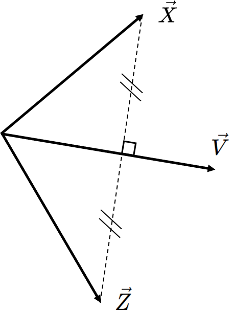

(a) Is a reflection transformation linear?

(b) If yes, find matrix $M$ such that $Z = MX$

(c) For $V = \begin{bmatrix} 1 & 1 \end{bmatrix}^T$, compute $M$ and its eigenvalues/eigenvectors (here, vector $V$ is a 45 degree angle to the x-axis.)

## Solution 05

(a) Suppose $f(X_1) = Z_1, f(X_2) = Z_2$ where $f$ is a reflection.

$\;\;\;$ 1) $f(\alpha x_1) = \alpha f(x_1)$

$\;\;\;$ 2) $f(x_1 + x_2) = f(x_1) + f(x_2)$

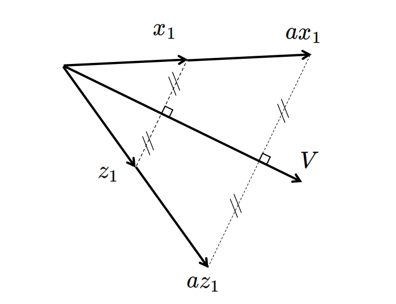

Think about the geometric definition of a reflection. We can easily show that it is a linear transformation.

(b)

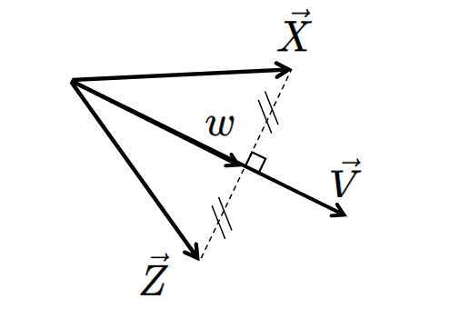

We learned

$$\begin{align*} \omega &= PX = \frac{v^Tx}{v^Tv}v = \frac{vv^T}{v^Tv}X\\\\ z &= x = 2(\omega - x) = 2\omega -x\\\\ &= \left( 2\frac{vv^T}{v^Tv} - I \right)X = MX \end{align*}$$

(c)

$$\begin{align*} V &= \begin{bmatrix}1\\ 1\end{bmatrix}\\ \\ M &= 2\frac{\begin{bmatrix}1\\ 1 \end{bmatrix}\begin{bmatrix}1&1\end{bmatrix}}{\begin{bmatrix}1& 1 \end{bmatrix}\begin{bmatrix}1 \\ 1\end{bmatrix}} - \begin{bmatrix} 1 & 0 \\ 0 & 1 \end{bmatrix} = \begin{bmatrix} 0 & 1 \\ 1 & 0 \end{bmatrix} \end{align*}$$

Can you come up with a reflection transformation by just looking at matrix $\begin{bmatrix} 0 & 1 \\ 1 & 0 \end{bmatrix}$ ?

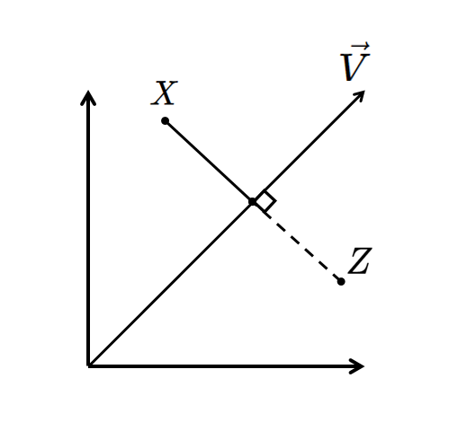

$$\begin{align*} \text{if } x = \begin{bmatrix} x_1\\ x_2 \end{bmatrix} &\implies Z = \begin{bmatrix} 0 & 1 \\ 1 & 0 \end{bmatrix}\begin{bmatrix} x_1\\ x_2 \end{bmatrix} = \begin{bmatrix} x_2\\ x_1 \end{bmatrix}\\\\ Mx = \lambda x &\implies \left(M - \lambda I \right)x = 0\\\\ \text{det} \begin{bmatrix}-\lambda & 1 \\ 1 & -\lambda \end{bmatrix} &= \lambda^2 - 1 = 0 \implies \lambda = \pm 1 \end{align*}$$

$$\begin{align*} \text{For } \lambda_1 = 1, x_1 &= \begin{bmatrix}1 \\ 1 \end{bmatrix}\\\\ \text{For } \lambda_2 = -1, x_2 &= \begin{bmatrix}1 \\ -1 \end{bmatrix}\\ \end{align*}$$

$\implies $ think about these two eigenvectors with a reflection transformation

# Problem 06

A linear map $P: X \rightarrow X$ acting on a vector space $X$ is called a projection if $P^2 = P$.

(a) Show that the matrix $P = \begin{bmatrix} 0& 1\\ 0& 1 \end{bmatrix}$ is a projection. Draw a sketch of $\mathbb{R}^2$ showing the vectors $[1, 2]^T$, $[−1, 0]^T$, and $[0, 3]^T$ and their images under the map $P$.

(b) Repeat this for $Q = I − P$.

## Solution 06

(a)

$$ \begin{align*} P^2 = \begin{bmatrix} 0& 1\\ 0& 1 \end{bmatrix} \times \begin{bmatrix} 0& 1\\ 0& 1 \end{bmatrix} = \begin{bmatrix} 0& 1\\ 0& 1 \end{bmatrix} = P \implies P \; \text{is a projection} \end{align*} $$

$$ \begin{align*} P \,\begin{bmatrix} 1 & 2 \end{bmatrix}^T &= \begin{bmatrix} 2 & 2 \end{bmatrix}^T\\ P \,\begin{bmatrix} -1 & 0 \end{bmatrix}^T &= \begin{bmatrix} 0 & 0 \end{bmatrix}^T\\ P \,\begin{bmatrix} 0 & 3 \end{bmatrix}^T &= \begin{bmatrix} 3 & 3 \end{bmatrix}^T \end{align*} $$

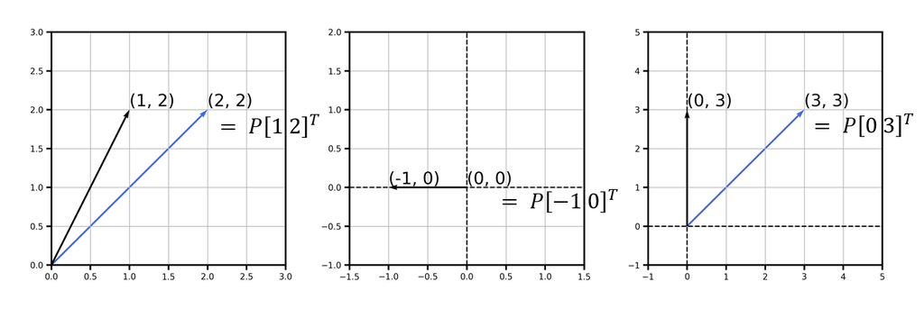

As shown in figure,we can find $P$ is a projection of points on the line $y = x$

(b)

$$ Q^2 = (I-P)^2 = I-2P +P^2 = I- P = Q \implies Q \; \text{is a projection}\\ Q = I-P = \begin{bmatrix} 1& -1\\ 0& 0 \end{bmatrix} $$

$$ \begin{align*} Q \,\begin{bmatrix} 1 & 2 \end{bmatrix}^T &= \begin{bmatrix} -1 & 0 \end{bmatrix}^T\\ Q \,\begin{bmatrix} -1 & 0 \end{bmatrix}^T &= \begin{bmatrix} -1 & 0 \end{bmatrix}^T\\ Q \,\begin{bmatrix} 0 & 3 \end{bmatrix}^T &= \begin{bmatrix} -3 & 0 \end{bmatrix}^T \end{align*} $$

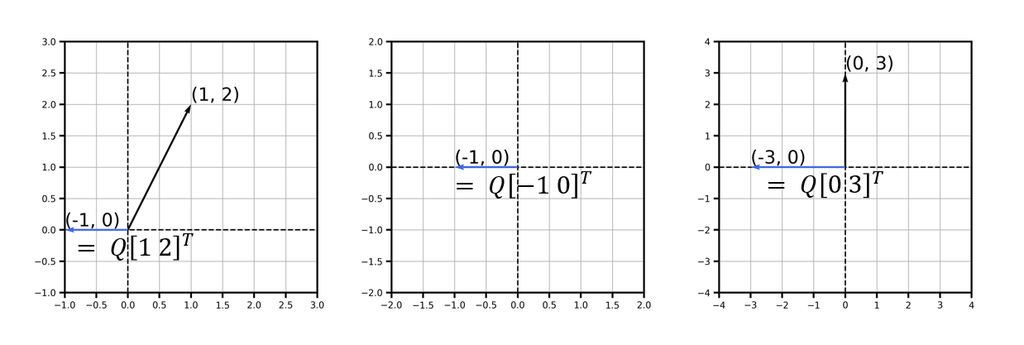

As shown in the above figure, we can find $Q$ is a projection of points on the line $y = 0$

# Problem 07

Consider projection transformation of a vector $x$ on a given vector $y$. Let $y$ be a given $n$-vector, and consider the function $f : \mathbb{R}^n \Rightarrow \mathbb{R}^n$, defined as

$$f(x) = \frac{x^Ty}{\lVert y\rVert^2}y$$

We know that $f(x)$ is the projection of $x$ on the (fixed, given) vector $y$.

Is $f$ a linear function of $x$?

- If your answer is yes, provide an $n \times n$ matrix $A$ such that $f(x) = Ax$ for all $x$ .
- If your answer is no, show with an example that $f$ does not satisfy the definition of linearity $f(\alpha u + \beta v) = \alpha f(u) + \beta f(v)$.

# Problem 08

Let $v \in \mathbb{R}^n$ be a unit vector and $Px$ the orthogonal projection of $x \in \mathbb{R}^n$ in the direction of $v$, that is, if $x = cv$ for some real constant $c$, then $Px = x$, while if $x \perp v$, then $Px = 0$. Show that $P = v v^T$

## Solution 08

By definition of projection, we can obtain

$$ Px = \frac{v^Tx}{v^Tv}v = \frac{vv^T}{v^Tv}x \implies P = \frac{vv^T}{v^Tv} \quad (\because v(v \cdot x) = v(v^Tx) = (v^Tv)x) $$

Then, we can use a property of unit vector $v^Tv = \lVert v\rVert^2 = 1$ and $P$ is expressed as the following :

$$ P = vv^T $$

# Problem 09

Suppose $T_1$ and $T_2$ are linear transformations from vector space $V$ to itself. Note that $T_1$ and $T_2$ are not in a form of matrix.

(a) Prove that mapping $T_1 + T_2$ is a linear transformation.

(b) Prove that mapping $T_1 \cdot T_2$ is a linear transformation.

# Problem 10

Represent each of the following three functions $f: \mathbb{R}^2 \rightarrow \mathbb{R}^2$ as a matrix-vector product $f(x) = Ax$

(a) $f(x)$ is obtained by reflecting $x$ about the $x_1$ axis

(b) $f(x)$ is $x$ reflected about the $x_1$ axis, followed by a counter clockwise rotation of 30 degrees.

(c) $f(x)$ is $x$ rotated counterclockwise over 30 degrees, followed by a reflection about the $x_1$ axis

# Problem 11

Let $A$ be an invertible matrix with eigenvalues $\lambda_1, \lambda_2,\cdots,\lambda_k$ and corresponding eigenvectors $v_1, v_2, \cdots ,v_k$. What can you say about the eigenvalues and eigenvectors of $A^{−1}$? Justify your response.

## Solution 11

$$\begin{align*} Av &= \lambda v\\ A^{-1}Av &= A^{-1} \lambda v \implies v = A^{-1} \lambda v\\ \end{align*}$$

$$ A^{-1}v = \frac{1}{\lambda}v $$

Therefore,

$$ \begin{align*} A^{-1}\text{'s eigenvalues are }\frac{1}{\lambda} &\implies \frac{1}{\lambda_1}, \frac{1}{\lambda_2}, \frac{1}{\lambda_3},\cdots \frac{1}{\lambda_k}\\\\ A^{-1}\text{'s eigenvectors are } v &\implies v_1, v_2, v_3, \cdots v_k \end{align*} $$

# Problem 12

Fibonacci sequence is defined as the follwing:

$$F_{k+2} = F_{k+1} + F_{k} \qquad \text{with} \;F_0 = 0, \;F_1 = 1$$

It is known that the ratio of $F_{k+1}$ to $F_{k}$ is close to 'golden mean'. That is,

$$\lim_{k \to \infty} \frac{F_{k+1}}{F_{k}} = \frac{\left(1 + \sqrt{5}\right)}{2}$$

Show the above equation using eigenvectors and eigenvalues.

- Hint. Write fibonacci sequence in matrix form

# Problem 13

Let's assume a transformation $T : \mathbb{R}^2 \to \mathbb{R}^2$ projects an arbitrary vector onto a space spanned by $x = [1, 1]^T$.

Find the corresponding matrix $A$ by using

(a) Eigen decomposition (in other words, see how two eigenvectos are transformed by $T$) and

(b) Projection matrix.

# Problem 14

There are system of equations

$$ \begin{align*} 83x + 12y + 10z &= 141 \\ -68x + 84y + 95z &= 145 \\ 32x + 23y + 43z &= 89 \end{align*} $$

(a) Write the equations in a matrix form. ($AX = B$)

```python
# Write your code here
# A =
# B =
```

(b) Does this system of equations have a solution?

- If yes, find the solution of system of equations
- If no, find the solution of system of equations that minimizes $\lVert AX-B \rVert $

```python
# Write your code here
# X_opt =
```

# Problem 15

Solve the following optimization problem:

$$\begin{align*} \min \quad &\rVert x \lVert \\ \text{subjec to}\quad &2x_1 - x_2 + x_3 -x_4 = 3\\ &\qquad \,\, x_2 - x_3 - x_4 = 1 \end{align*}$$

## Solution 15

This problem can be written in a linear matrix form $Ax = b$,

$$ \begin{align*} \begin{bmatrix}2 & -1 & 1 & -1 \\ 0 & 1 & -1 & -1\end{bmatrix}\begin{bmatrix}x_1 \\ x_2 \\ x_3 \\ x_4 \end{bmatrix} &= \begin{bmatrix} 3 \\ 1 \end{bmatrix} \end{align*} $$

Then, we can obtain the optimal value of $x$ using the least norm solution formula as the following :

$$ x^* = A^T(AA^T)^{-1}b $$

Therefore,

$$\begin{align*} x^* &= \begin{bmatrix}2 & 0 \\ -1 & 1 \\ 1 & -1 \\ -1 & -1\end{bmatrix}(\begin{bmatrix}2 & -1 & 1 & -1 \\ 0 & 1 & -1 & -1\end{bmatrix}\begin{bmatrix}2 & 0 \\ -1 & 1 \\ 1 & -1 \\ -1 & -1\end{bmatrix}^T)^{-1}\begin{bmatrix} 3 \\ 1 \end{bmatrix} \\ &= \begin{bmatrix}2 & 0 \\ -1 & 1 \\ 1 & -1 \\ -1 & -1\end{bmatrix}\frac{1}{20}\begin{bmatrix}3 & 1 \\ 1 & 7\end{bmatrix} \begin{bmatrix} 3 \\ 1 \end{bmatrix}= \frac{1}{20}\begin{bmatrix} 20 \\ 0 \\ 0 \\ -20 \end{bmatrix}\\ &= \begin{bmatrix} 1 \\ 0 \\ 0 \\ -1 \end{bmatrix} \end{align*}$$